# Homework 4: Poisson and Overdispersion

Jamie Ash

due: 2021-09-22

# 1 Poisson Distribution No Interaction

Create a model where the count of kole is a function of turf algae, hard coral, sand, and crustose coralline algae. For now, include all these terms in the model, because we are interested in all of them as potential drivers of abundance. Use a poisson distribution to model the count distribution. Using likelihood ratio tests for the model terms, which appear to be significantly related to kole abundance? Plot the fitted model effects (it may be easiest to see the relationships with the yaxis on a log scale for this model). Based on these plots, which substrate types are predicted to have the largest effect on abundance? You can also compare the slope coefficients for the predictors, because all the predictors are measured on the same scale (percent cover)

## 1.1 Answer

[output not shown]

### 1.1.1 Poisson GLM

```r
infile <- "..\\data\\"
fish   <- read.csv(paste(infile, "CRCP_Reef_Fish_Surveys_Hawaii_kole.csv",
                         sep = ""))

model_noint <- glm(count ~ sand + ta +cca + hard_coral, data = fish,
                           family = poisson)
#summary(model_noint)

Anova(model_noint)
```

```
## Analysis of Deviance Table (Type II tests)
##
## Response: count
##            LR Chisq Df Pr(>Chisq)
## sand          6.645  1   0.009942 **
## ta           75.529  1  < 2.2e-16 ***
## cca         231.100  1  < 2.2e-16 ***
## hard_coral  230.581  1  < 2.2e-16 ***
## ---
## Signif. codes:  0 '***' 0.001 '**' 0.01 '*' 0.05 '.' 0.1 ' ' 1
```

### 1.1.2 GLM Scatterplots

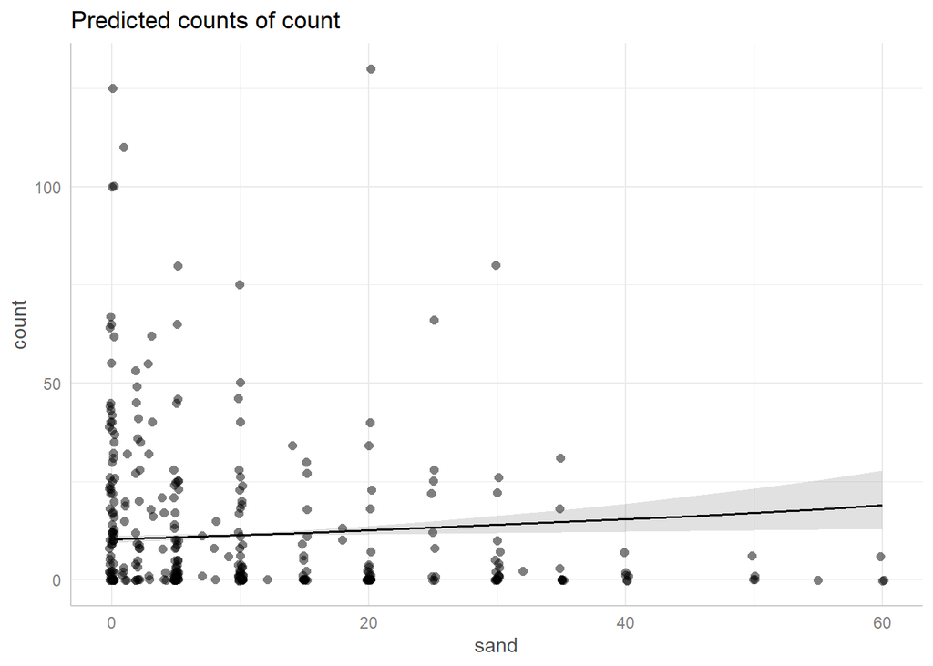

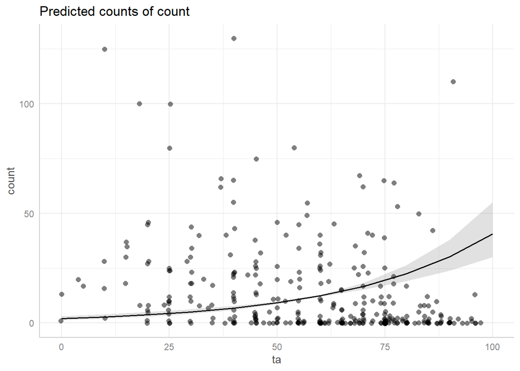

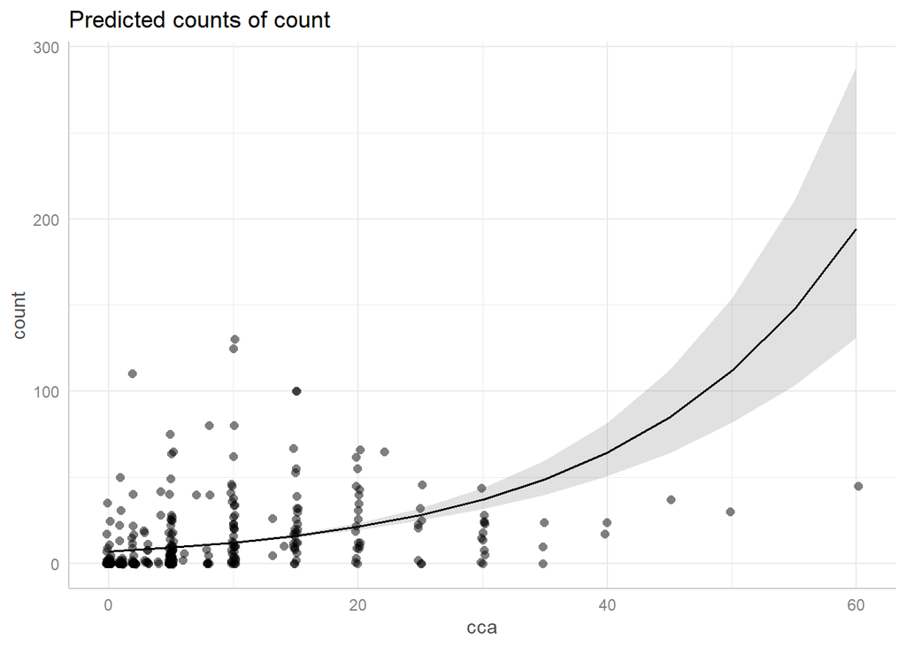

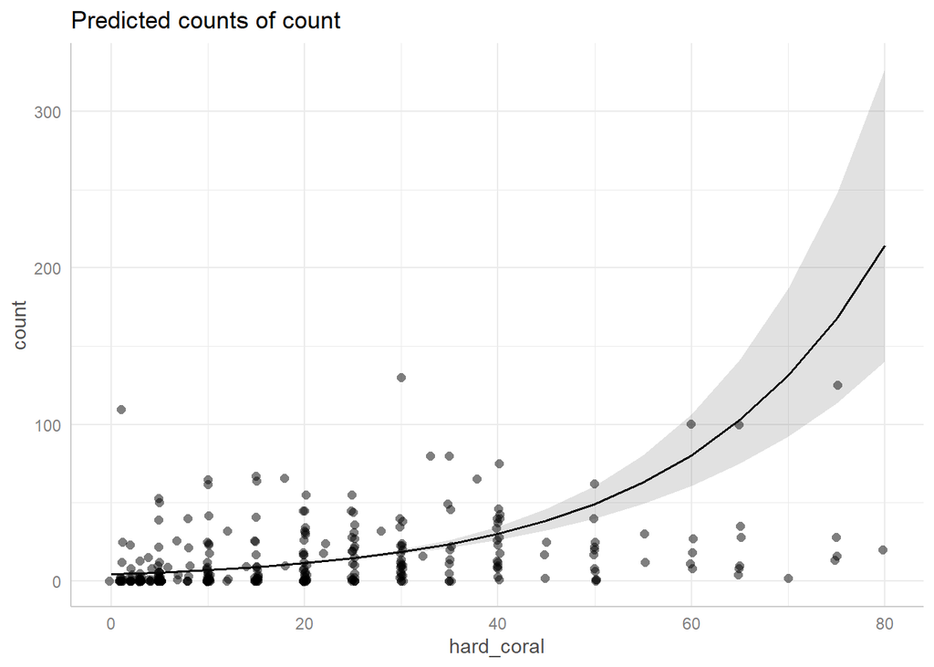

```r
figs <- plot(ggeffect(model_noint, log.y = TRUE), add.data = TRUE)
for (i in 1:4) print(figs[[i]])
```

# 2 Quasipoisson GLM

In the previous model we did not consider overdispersion, which means that the counts may have more variation than predicted by the poisson distribution. Now use a quasipoisson model instead. How much overdispersion is there, based on this model? How does accounting for overdispersion change the results? Which aspects of the model have changed, and which have not?

## 2.1 Answer

```r
model <- glm(count ~ sand + ta + cca + hard_coral,
             data = fish,
             family = quasipoisson)

modelsum <- summary(model)
```

[output not shown]

### 2.1.1 Summary Table

```r
Anova(model, test = 'F')
```

```
## Analysis of Deviance Table (Type II tests)
##
## Response: count
## Error estimate based on Pearson residuals
##
##            Sum Sq  Df F value   Pr(>F)
## sand          6.6   1  0.2467 0.619733
## ta           75.5   1  2.8045 0.095026 .
## cca         231.1   1  8.5810 0.003653 **
## hard_coral  230.6   1  8.5617 0.003691 **
## Residuals  8214.2 305
## ---
## Signif. codes:  0 '***' 0.001 '**' 0.01 '*' 0.05 '.' 0.1 ' ' 1
```

### 2.1.2 GLM Scatterplots

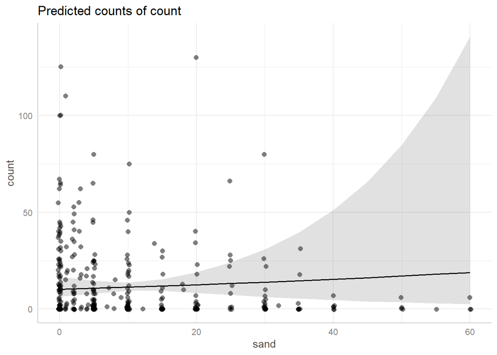

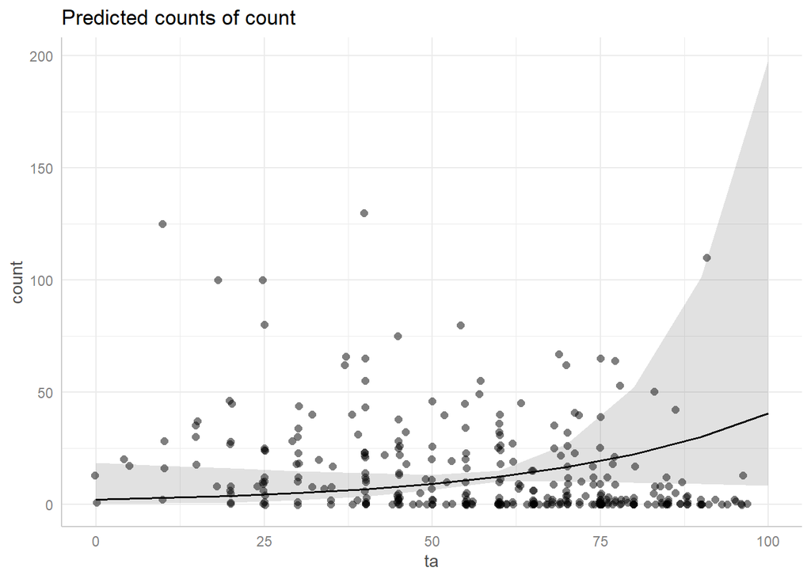

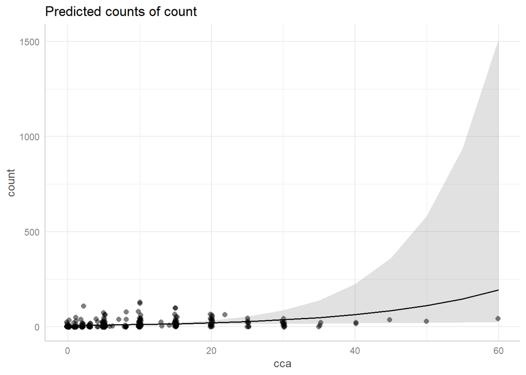

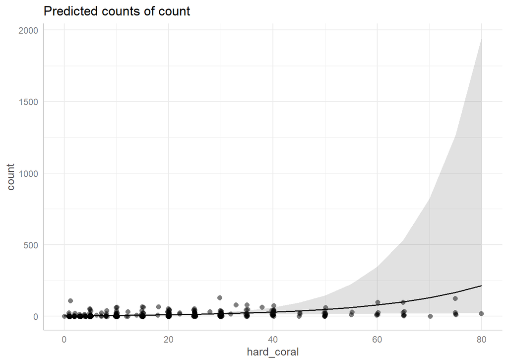

```r
figs <- plot(ggeffect(model), add.data= TRUE)
for (i in 1:length(figs)) print(figs[[i]])
```

# 3 Negative Binomial GLM

Another option for overdispersed counts is to use a negative binomial distribution instead of a poisson distribution. How do the results from a negative binomial model compare to the quasipoisson approach?

## 3.1 Answer

[output not shown]

### 3.1.1 Summary Tables

```r
model <- glm.nb(count ~ ta+ sand + cca + hard_coral,
             data = fish)

# summary(model)

Anova(model, test = 'F')
```

```
## Analysis of Deviance Table (Type II tests)
##
## Response: count
## Error estimate based on Pearson residuals
##
##            Sum Sq  Df F value   Pr(>F)
## ta           6.29   1  4.1573 0.042318 *
## sand         1.09   1  0.7239 0.395546
## cca         16.46   1 10.8788 0.001088 **
## hard_coral  14.39   1  9.5143 0.002225 **
## Residuals  461.38 305
## ---
## Signif. codes:  0 '***' 0.001 '**' 0.01 '*' 0.05 '.' 0.1 ' ' 1
```

### 3.1.2 GLM Scatterplots

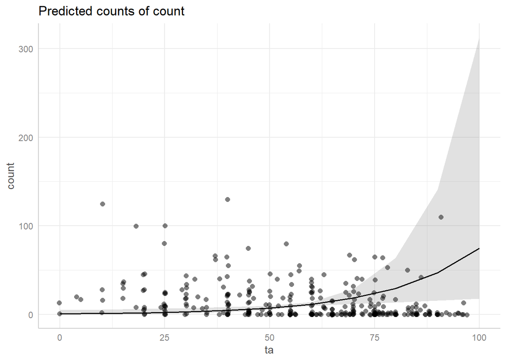

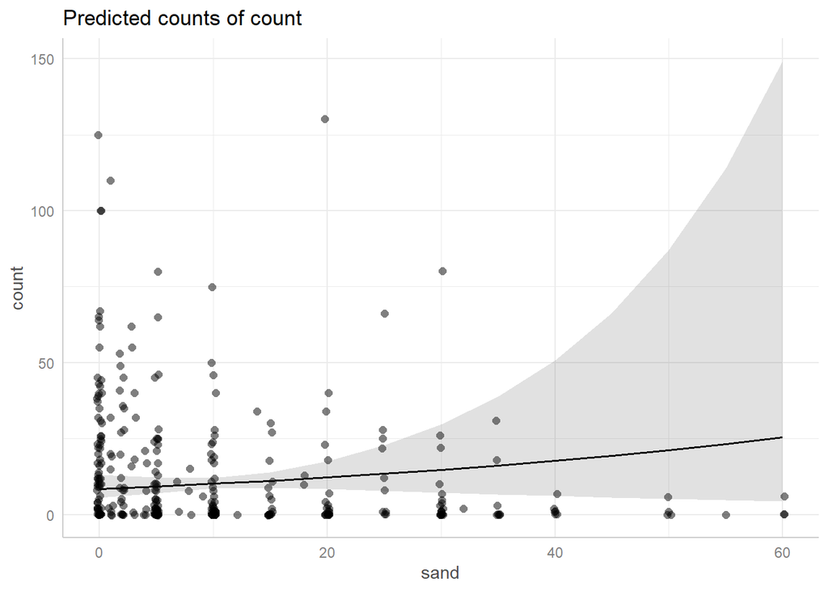

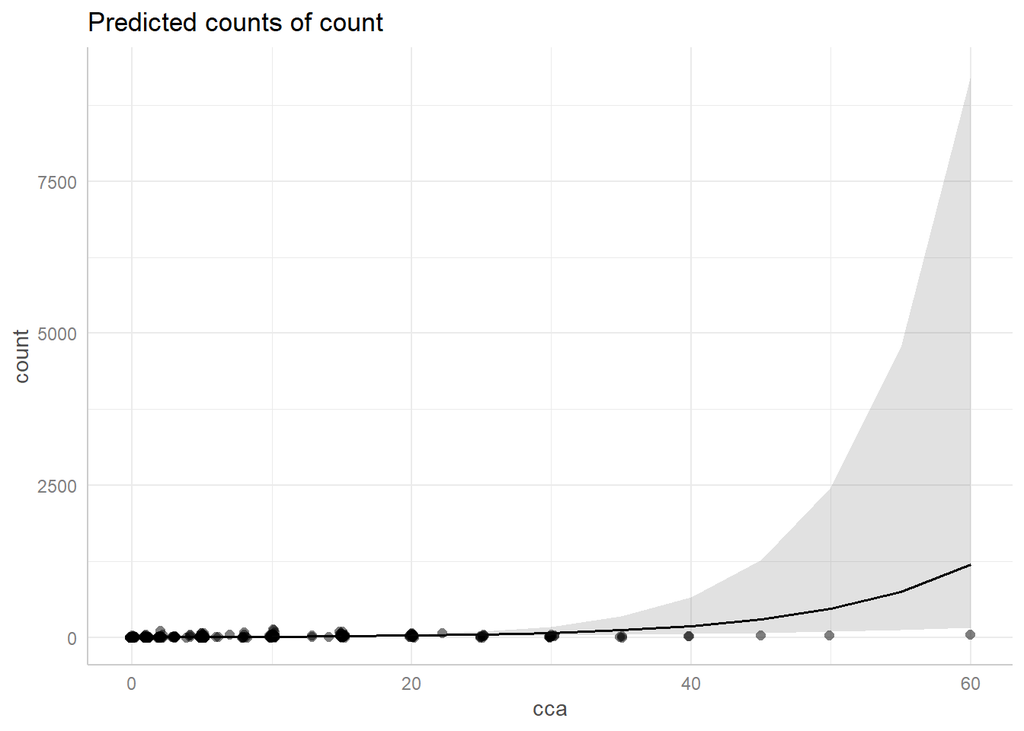

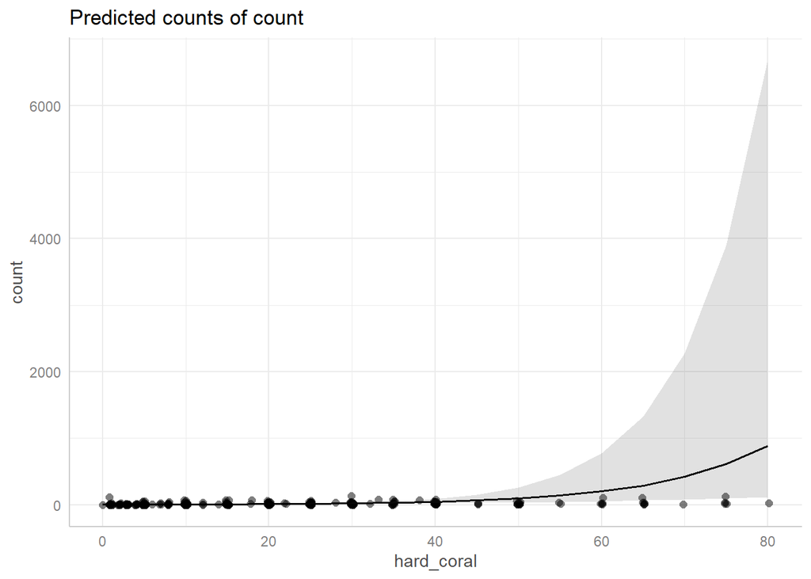

```r
figs <- plot(ggeffect(model), add.data= TRUE)
for (i in 1:4) print(figs[[i]])
```

# 4 Two new models

One of the main challenges in trying to decipher patterns from survey data is that ‘correlation is not causation’. Make two new models, one where sand is the only predictor, and one where turf algae is the only predictor. For both models use the negative binomial distribution. How do the results of these models differ from the model in #3, where all four predictors were included together? What do you think could explain why the results have changed? It may help to look at a correlogram of the predictors. The function ggpairs() in the package GGally is particularly nice for this (note: I am not requiring you to make a correlogram here, but you may find it helpful).

## 4.1 Answers

[output not shown]

### 4.1.1 Summary Tables

```r
model_sand <- glm.nb(count ~ sand, data = fish)
model_ta   <- glm.nb(count ~ ta,   data = fish)

Anova(model_sand, test = 'F')
```

```
## Analysis of Deviance Table (Type II tests)
##
## Response: count
## Error estimate based on Pearson residuals
##
##            Sum Sq  Df F value    Pr(>F)
## sand       17.888   1  18.842 1.928e-05 ***
## Residuals 292.398 308
## ---
## Signif. codes:  0 '***' 0.001 '**' 0.01 '*' 0.05 '.' 0.1 ' ' 1
```

```r
Anova(model_ta,   test = 'F')
```

```
## Analysis of Deviance Table (Type II tests)
##
## Response: count
## Error estimate based on Pearson residuals
##
##            Sum Sq  Df F value    Pr(>F)
## ta         19.342   1  19.592 1.333e-05 ***
## Residuals 304.074 308
## ---
## Signif. codes:  0 '***' 0.001 '**' 0.01 '*' 0.05 '.' 0.1 ' ' 1
```

### 4.1.2 GLM Scatterplots

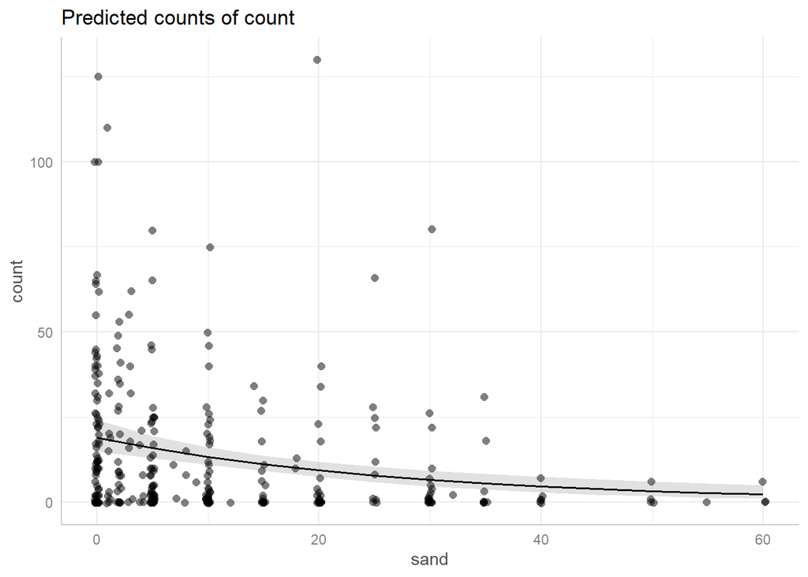

```r
plot(ggeffect(model_sand), add.data= TRUE)$sand
```

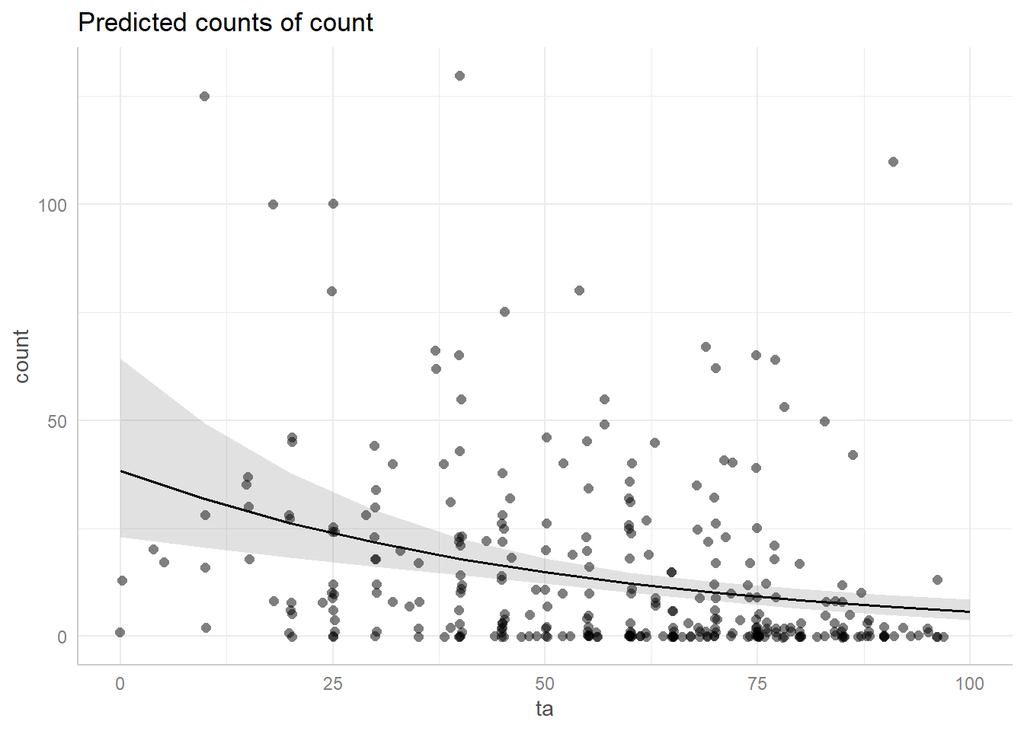

```r
plot(ggeffect(model_ta),   add.data= TRUE)$ta
```

### 4.1.3 Correlogram

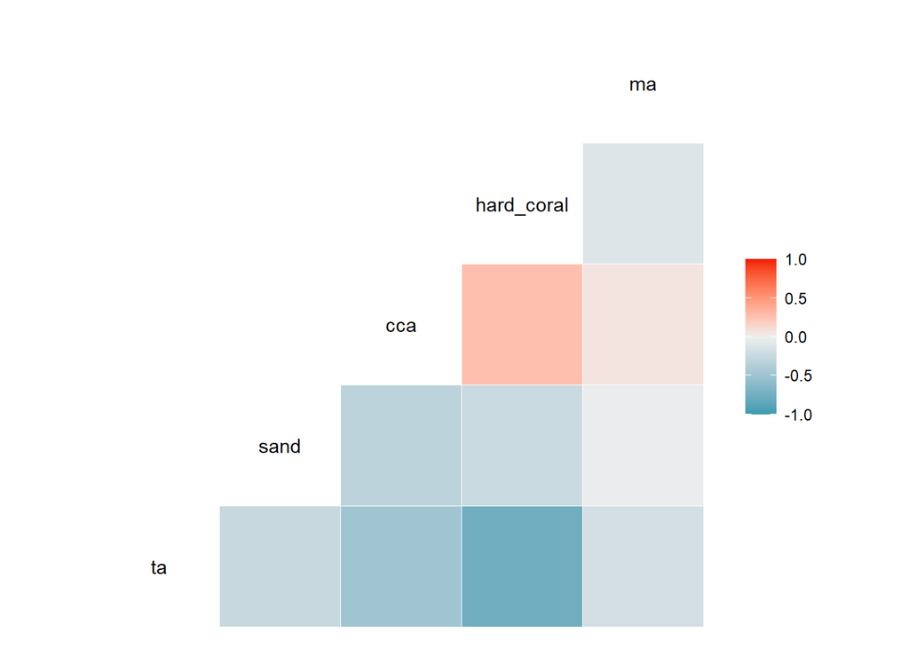

```r
# Quick display of two cabapilities of GGally, to assess the distribution and correlation of variables
library(GGally)

# Create data
fishes <- fish[,c("ta", "sand", "cca", "hard_coral", "ma")]
# Check correlations (as scatterplots), distribution and print corrleation coefficient
ggcorr(fishes, method = c("everything", "pearson"))
```

# 5 Final Question

Finally, what are your overall conclusions about substrate associations of kole, from this look at the data

## 5.1 Answer

[output not shown]

### 5.1.1 Summary Tables

```r
fish$both <- fish$hard_coral + fish$cca

model <- glm(count ~ sand + ta + I(hard_coral + cca),
             data = fish,
             family = quasipoisson)

modelsum <- summary(model)
Anova(model, test = 'F')
```

```
## Analysis of Deviance Table (Type II tests)
##
## Response: count
## Error estimate based on Pearson residuals
##
##                     Sum Sq  Df F value   Pr(>F)
## sand                   3.8   1  0.1412 0.707372
## ta                    68.3   1  2.5558 0.110919
## I(hard_coral + cca)  231.4   1  8.6548 0.003511 **
## Residuals           8182.9 306
## ---
## Signif. codes:  0 '***' 0.001 '**' 0.01 '*' 0.05 '.' 0.1 ' ' 1
```

```r
model <- glm.nb(count ~ ta+ sand + I(hard_coral + cca),
             data = fish)
Anova(model, test = 'F')
```

```
## Analysis of Deviance Table (Type II tests)
##
## Response: count
## Error estimate based on Pearson residuals
##
##                     Sum Sq  Df F value   Pr(>F)
## ta                    5.56   1  3.8226 0.051477 .
## sand                  0.63   1  0.4360 0.509578
## I(hard_coral + cca)  14.70   1 10.1115 0.001624 **
## Residuals           444.93 306
## ---
## Signif. codes:  0 '***' 0.001 '**' 0.01 '*' 0.05 '.' 0.1 ' ' 1
```